# hw2

Audrey Comer

1/31/2019

```r
a0 <- 1
a0
```

```
## [1] 1
```

1. Today’s temperature has a high of 15 and a low of -10 degree fahrenheit. Find the corresponding degrees in celsius and storage it in a (single) vector named `cel`. Print the variable.

```r
f <- c(-10:15)
cel <- (5/9*f)-32
cel
```

```
##  [1] -37.55556 -37.00000 -36.44444 -35.88889 -35.33333 -34.77778 -34.22222
##  [8] -33.66667 -33.11111 -32.55556 -32.00000 -31.44444 -30.88889 -30.33333
## [15] -29.77778 -29.22222 -28.66667 -28.11111 -27.55556 -27.00000 -26.44444
## [22] -25.88889 -25.33333 -24.77778 -24.22222 -23.66667
```

2. Create a vector of length 200. The odd entries should be 1 and even entries should be 0. Storage the created in a variable named `vec200` and print.

```r
vec200 <- rep(c(1,0),100)
vec200
```

```
##   [1] 1 0 1 0 1 0 1 0 1 0 1 0 1 0 1 0 1 0 1 0 1 0 1 0 1 0 1 0 1 0 1 0 1 0 1
##  [36] 0 1 0 1 0 1 0 1 0 1 0 1 0 1 0 1 0 1 0 1 0 1 0 1 0 1 0 1 0 1 0 1 0 1 0
##  [71] 1 0 1 0 1 0 1 0 1 0 1 0 1 0 1 0 1 0 1 0 1 0 1 0 1 0 1 0 1 0 1 0 1 0 1
## [106] 0 1 0 1 0 1 0 1 0 1 0 1 0 1 0 1 0 1 0 1 0 1 0 1 0 1 0 1 0 1 0 1 0 1 0
## [141] 1 0 1 0 1 0 1 0 1 0 1 0 1 0 1 0 1 0 1 0 1 0 1 0 1 0 1 0 1 0 1 0 1 0 1
## [176] 0 1 0 1 0 1 0 1 0 1 0 1 0 1 0 1 0 1 0 1 0 1 0 1 0
```

3. How many perfect squares are there between 1 and 1001? Storage the answer in a variable named `numPerfect` and print. You may want to look at `?round`.

```r
sqrt(1001)
```

```
## [1] 31.63858
```

```r
numPerfect <- floor(sqrt(1001))
numPerfect
```

```
## [1] 31
```

```r
library(ggplot2)
```

What are the 3 most fuel-efficient models in terms of highway mileage? Storage the data frame (with 3 rows) containing all information of these three cars in a variable named top3 and print.

```r
summary(mpg)
```

```
##  manufacturer          model               displ            year
##  Length:234         Length:234         Min.   :1.600   Min.   :1999
##  Class :character   Class :character   1st Qu.:2.400   1st Qu.:1999
##  Mode  :character   Mode  :character   Median :3.300   Median :2004
##                                        Mean   :3.472   Mean   :2004
##                                        3rd Qu.:4.600   3rd Qu.:2008
##                                        Max.   :7.000   Max.   :2008
##       cyl           trans               drv                 cty
##  Min.   :4.000   Length:234         Length:234         Min.   : 9.00
##  1st Qu.:4.000   Class :character   Class :character   1st Qu.:14.00
##  Median :6.000   Mode  :character   Mode  :character   Median :17.00
##  Mean   :5.889                                         Mean   :16.86
##  3rd Qu.:8.000                                         3rd Qu.:19.00
##  Max.   :8.000                                         Max.   :35.00
##       hwy             fl               class
##  Min.   :12.00   Length:234         Length:234
##  1st Qu.:18.00   Class :character   Class :character
##  Median :24.00   Mode  :character   Mode  :character
##  Mean   :23.44
##  3rd Qu.:27.00
##  Max.   :44.00
```

```r
highway <- mpg$hwy
highway
```

```
##   [1] 29 29 31 30 26 26 27 26 25 28 27 25 25 25 25 24 25 23 20 15 20 17 17
##  [24] 26 23 26 25 24 19 14 15 17 27 30 26 29 26 24 24 22 22 24 24 17 22 21
##  [47] 23 23 19 18 17 17 19 19 12 17 15 17 17 12 17 16 18 15 16 12 17 17 16
##  [70] 12 15 16 17 15 17 17 18 17 19 17 19 19 17 17 17 16 16 17 15 17 26 25
##  [93] 26 24 21 22 23 22 20 33 32 32 29 32 34 36 36 29 26 27 30 31 26 26 28
## [116] 26 29 28 27 24 24 24 22 19 20 17 12 19 18 14 15 18 18 15 17 16 18 17
## [139] 19 19 17 29 27 31 32 27 26 26 25 25 17 17 20 18 26 26 27 28 25 25 24
## [162] 27 25 26 23 26 26 26 26 25 27 25 27 20 20 19 17 20 17 29 27 31 31 26
## [185] 26 28 27 29 31 31 26 26 27 30 33 35 37 35 15 18 20 20 22 17 19 18 20
## [208] 29 26 29 29 24 44 29 26 29 29 29 29 23 24 44 41 29 26 28 29 29 29 28
## [231] 29 26 26 26
```

```r
names(highway) <- mpg$model
highway
```

```
##                     a4                     a4                     a4
##                     29                     29                     31
##                     a4                     a4                     a4
##                     30                     26                     26
##                     a4             a4 quattro             a4 quattro
##                     27                     26                     25
##             a4 quattro             a4 quattro             a4 quattro
##                     28                     27                     25
##             a4 quattro             a4 quattro             a4 quattro
##                     25                     25                     25
##             a6 quattro             a6 quattro             a6 quattro
##                     24                     25                     23
##     c1500 suburban 2wd     c1500 suburban 2wd     c1500 suburban 2wd
##                     20                     15                     20
##     c1500 suburban 2wd     c1500 suburban 2wd               corvette
##                     17                     17                     26
##               corvette               corvette               corvette
##                     23                     26                     25
##               corvette        k1500 tahoe 4wd        k1500 tahoe 4wd
##                     24                     19                     14
##        k1500 tahoe 4wd        k1500 tahoe 4wd                 malibu
##                     15                     17                     27
##                 malibu                 malibu                 malibu
##                     30                     26                     29
##                 malibu            caravan 2wd            caravan 2wd
##                     26                     24                     24
##            caravan 2wd            caravan 2wd            caravan 2wd
##                     22                     22                     24
##            caravan 2wd            caravan 2wd            caravan 2wd
##                     24                     17                     22
##            caravan 2wd            caravan 2wd            caravan 2wd
##                     21                     23                     23
##      dakota pickup 4wd      dakota pickup 4wd      dakota pickup 4wd
##                     19                     18                     17
##      dakota pickup 4wd      dakota pickup 4wd      dakota pickup 4wd
##                     17                     19                     19
##      dakota pickup 4wd      dakota pickup 4wd      dakota pickup 4wd
##                     12                     17                     15
##            durango 4wd            durango 4wd            durango 4wd
##                     17                     17                     12
```

[output cut: 101 more lines]

```
##                     29                     24                     44
##                  jetta                  jetta                  jetta
##                     29                     26                     29
##                  jetta                  jetta                  jetta
##                     29                     29                     29
##                  jetta                  jetta             new beetle
##                     23                     24                     44
##             new beetle             new beetle             new beetle
##                     41                     29                     26
##             new beetle             new beetle                 passat
##                     28                     29                     29
##                 passat                 passat                 passat
##                     29                     28                     29
##                 passat                 passat                 passat
##                     26                     26                     26
```

```r
sort(highway, decreasing = TRUE)
```

```
##                  jetta             new beetle             new beetle
##                     44                     44                     41
##                corolla                  civic                  civic
##                     37                     36                     36
##                corolla                corolla                  civic
##                     35                     35                     34
##                  civic                corolla                  civic
##                     33                     33                     32
##                  civic                  civic                 altima
##                     32                     32                     32
##                     a4                 sonata                 altima
##                     31                     31                     31
##                  camry                  camry           camry solara
##                     31                     31                     31
##           camry solara                     a4                 malibu
##                     31                     30                     30
##                 sonata                corolla                     a4
##                     30                     30                     29
##                     a4                 malibu                  civic
##                     29                     29                     29
##                  civic                tiburon                 altima
##                     29                     29                     29
##                  camry           camry solara                    gti
##                     29                     29                     29
##                    gti                    gti                  jetta
##                     29                     29                     29
##                  jetta                  jetta                  jetta
##                     29                     29                     29
##                  jetta             new beetle             new beetle
##                     29                     29                     29
##                 passat                 passat                 passat
##                     29                     29                     29
##             a4 quattro                 sonata                tiburon
##                     28                     28                     28
##             grand prix                  camry             new beetle
##                     28                     28                     28
##                 passat                     a4             a4 quattro
##                     28                     27                     27
##                 malibu                 sonata                tiburon
##                     27                     27                     27
```

[output cut: 101 more lines]

```
##                     16                     16                     16
##    ram 1500 pickup 4wd        f150 pickup 4wd        f150 pickup 4wd
##                     16                     16                     16
##          navigator 2wd     c1500 suburban 2wd        k1500 tahoe 4wd
##                     16                     15                     15
##      dakota pickup 4wd            durango 4wd    ram 1500 pickup 4wd
##                     15                     15                     15
##    ram 1500 pickup 4wd        f150 pickup 4wd            range rover
##                     15                     15                     15
##            range rover land cruiser wagon 4wd        k1500 tahoe 4wd
##                     15                     15                     14
##     grand cherokee 4wd      dakota pickup 4wd            durango 4wd
##                     14                     12                     12
##    ram 1500 pickup 4wd    ram 1500 pickup 4wd     grand cherokee 4wd
##                     12                     12                     12
```

```r
head(highway, 3)
```

```
## a4 a4 a4
## 29 29 31
```

```r
top3model <- names(head(highway,3))
top3model
```

```
## [1] "a4" "a4" "a4"
```

```r
top3 <- mpg[mpg$hwy >40, ]
top3
```

```
## # A tibble: 3 x 11
##   manufacturer model  displ  year   cyl trans drv     cty   hwy fl    class
##   <chr>        <chr>  <dbl> <int> <int> <chr> <chr> <int> <int> <chr> <chr>
## 1 volkswagen   jetta    1.9  1999     4 manu… f        33    44 d     comp…
## 2 volkswagen   new b…   1.9  1999     4 manu… f        35    44 d     subc…
## 3 volkswagen   new b…   1.9  1999     4 auto… f        29    41 d     subc…
```

How many different compact models are included in this dataset? Storage the answer in a variable named numCompact and print.

```r
mpg$class
```

```
##   [1] "compact"    "compact"    "compact"    "compact"    "compact"
##   [6] "compact"    "compact"    "compact"    "compact"    "compact"
##  [11] "compact"    "compact"    "compact"    "compact"    "compact"
##  [16] "midsize"    "midsize"    "midsize"    "suv"        "suv"
##  [21] "suv"        "suv"        "suv"        "2seater"    "2seater"
##  [26] "2seater"    "2seater"    "2seater"    "suv"        "suv"
##  [31] "suv"        "suv"        "midsize"    "midsize"    "midsize"
##  [36] "midsize"    "midsize"    "minivan"    "minivan"    "minivan"
##  [41] "minivan"    "minivan"    "minivan"    "minivan"    "minivan"
##  [46] "minivan"    "minivan"    "minivan"    "pickup"     "pickup"
##  [51] "pickup"     "pickup"     "pickup"     "pickup"     "pickup"
##  [56] "pickup"     "pickup"     "suv"        "suv"        "suv"
##  [61] "suv"        "suv"        "suv"        "suv"        "pickup"
##  [66] "pickup"     "pickup"     "pickup"     "pickup"     "pickup"
##  [71] "pickup"     "pickup"     "pickup"     "pickup"     "suv"
```

[output cut: 32 more lines]

```r
compact <- mpg[mpg$class == "compact", ]
compact
```

```
## # A tibble: 47 x 11
##    manufacturer model displ  year   cyl trans drv     cty   hwy fl    class
##    <chr>        <chr> <dbl> <int> <int> <chr> <chr> <int> <int> <chr> <chr>
##  1 audi         a4      1.8  1999     4 auto… f        18    29 p     comp…
##  2 audi         a4      1.8  1999     4 manu… f        21    29 p     comp…
##  3 audi         a4      2    2008     4 manu… f        20    31 p     comp…
##  4 audi         a4      2    2008     4 auto… f        21    30 p     comp…
##  5 audi         a4      2.8  1999     6 auto… f        16    26 p     comp…
##  6 audi         a4      2.8  1999     6 manu… f        18    26 p     comp…
##  7 audi         a4      3.1  2008     6 auto… f        18    27 p     comp…
##  8 audi         a4 q…   1.8  1999     4 manu… 4        18    26 p     comp…
##  9 audi         a4 q…   1.8  1999     4 auto… 4        16    25 p     comp…
## 10 audi         a4 q…   2    2008     4 manu… 4        20    28 p     comp…
## # … with 37 more rows
```

```r
numCompact <- nrow(compact)
numCompact
```

```
## [1] 47
```

Create a scatterplot of hwy and cty and describe the relationship. Why are there so few points visible? So few points are visible because the data overlaps – there are multiple data points with the same (x,y) (hwy,cty) values as each other.

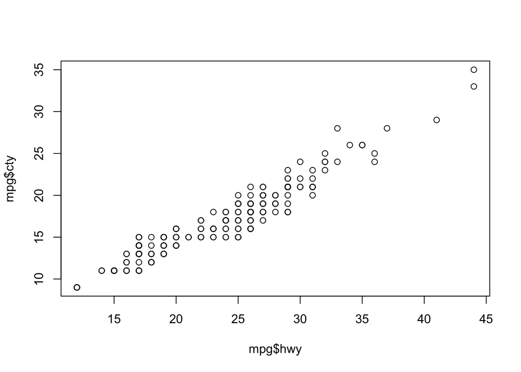

```r
plot(mpg$hwy, mpg$cty)
```

Are cars in 2008 more fuel efficient than cars in 1999? Use graphs and summary statistics to answer this question.

```r
y1999 <- mpg[mpg$year==1999,] #creates df of just 1999
y1999
```

```
## # A tibble: 117 x 11
##    manufacturer model displ  year   cyl trans drv     cty   hwy fl    class
##    <chr>        <chr> <dbl> <int> <int> <chr> <chr> <int> <int> <chr> <chr>
##  1 audi         a4      1.8  1999     4 auto… f        18    29 p     comp…
##  2 audi         a4      1.8  1999     4 manu… f        21    29 p     comp…
##  3 audi         a4      2.8  1999     6 auto… f        16    26 p     comp…
##  4 audi         a4      2.8  1999     6 manu… f        18    26 p     comp…
##  5 audi         a4 q…   1.8  1999     4 manu… 4        18    26 p     comp…
##  6 audi         a4 q…   1.8  1999     4 auto… 4        16    25 p     comp…
##  7 audi         a4 q…   2.8  1999     6 auto… 4        15    25 p     comp…
##  8 audi         a4 q…   2.8  1999     6 manu… 4        17    25 p     comp…
##  9 audi         a6 q…   2.8  1999     6 auto… 4        15    24 p     mids…
## 10 chevrolet    c150…   5.7  1999     8 auto… r        13    17 r     suv
## # … with 107 more rows
```

```r
y2008 <- mpg[mpg$year==2008,] #creates df of just 2008
y2008
```

```
## # A tibble: 117 x 11
##    manufacturer model displ  year   cyl trans drv     cty   hwy fl    class
##    <chr>        <chr> <dbl> <int> <int> <chr> <chr> <int> <int> <chr> <chr>
##  1 audi         a4      2    2008     4 manu… f        20    31 p     comp…
##  2 audi         a4      2    2008     4 auto… f        21    30 p     comp…
##  3 audi         a4      3.1  2008     6 auto… f        18    27 p     comp…
##  4 audi         a4 q…   2    2008     4 manu… 4        20    28 p     comp…
##  5 audi         a4 q…   2    2008     4 auto… 4        19    27 p     comp…
##  6 audi         a4 q…   3.1  2008     6 auto… 4        17    25 p     comp…
##  7 audi         a4 q…   3.1  2008     6 manu… 4        15    25 p     comp…
##  8 audi         a6 q…   3.1  2008     6 auto… 4        17    25 p     mids…
##  9 audi         a6 q…   4.2  2008     8 auto… 4        16    23 p     mids…
## 10 chevrolet    c150…   5.3  2008     8 auto… r        14    20 r     suv
## # … with 107 more rows
```

```r
y1999$mpg_avg <- rowMeans(y1999[c('hwy', 'cty')], na.rm=TRUE) #adds row for mean of hwy and city
y2008$mpg_avg <- rowMeans(y2008[c('hwy', 'cty')], na.rm=TRUE) #ditto
df <- rbind(y1999,y2008) #creates new df combining 1999 and 2008
```

Below is a box plot that show the average for 1999 was higher than 2008. However, outliers factor into this. Cars from 2008 had a wider distribution of MPG, especially for cars above the average.

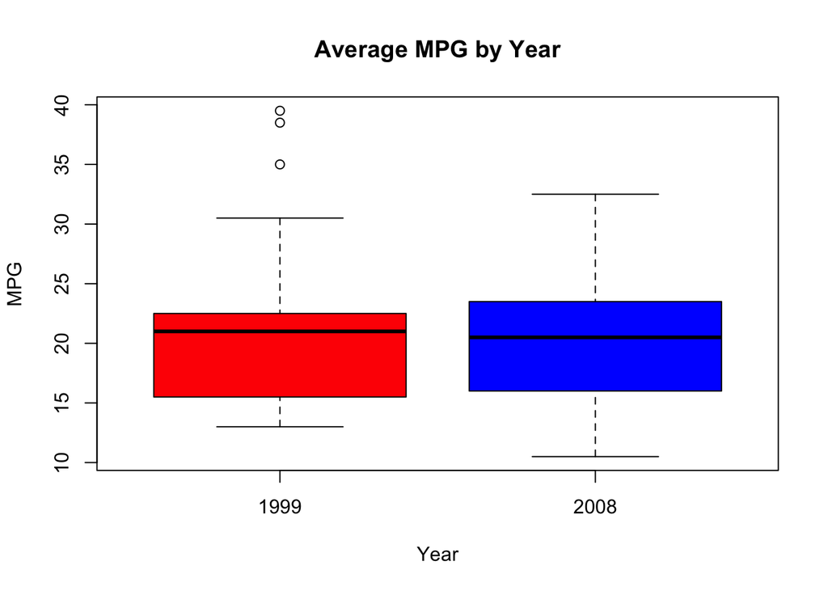

```r
?boxplot
boxplot(mpg_avg~year,data=df, col=c('red','blue'), main='Average MPG by Year',xlab='Year',ylab='MPG')
```

The third diagram below is a histogram showing average mpg of 1999 in red and 2008 in blue. We can see again that 2008 (blue) has a wider distribution in the middle range.

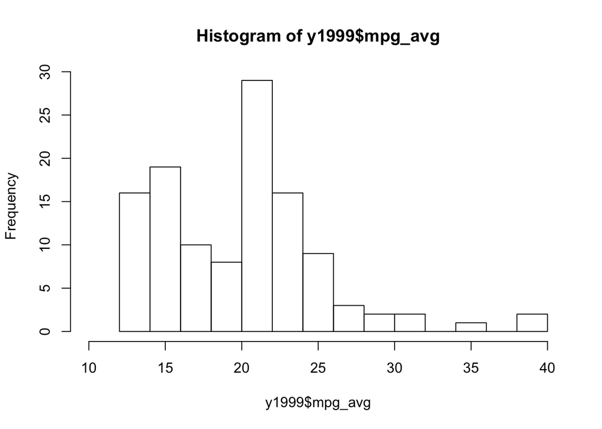

```r
p1 <- hist(x=y1999$mpg_avg,breaks=12,xlim=c(10,40)) #setting up 1999 histogram
```

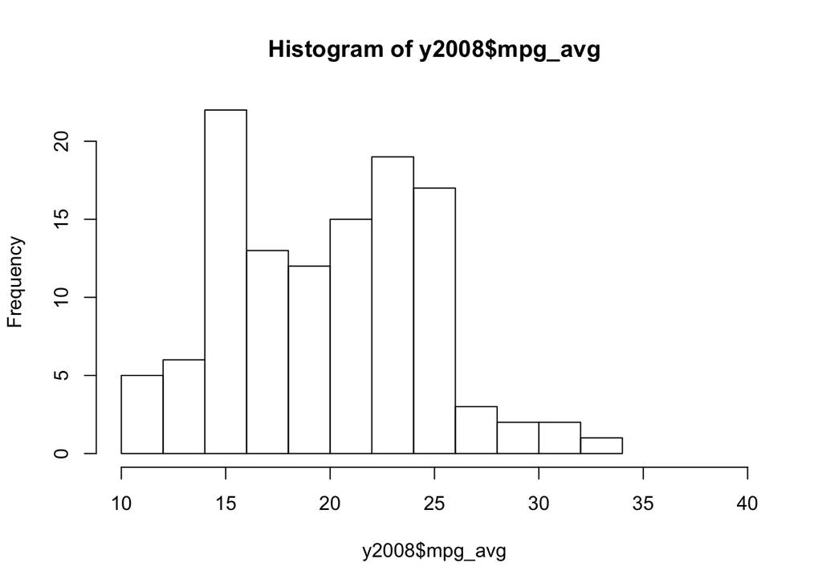

```r
p2 <- hist(x=y2008$mpg_avg,breaks=12,xlim=c(10,40)) #setting up 2008 histogram
```

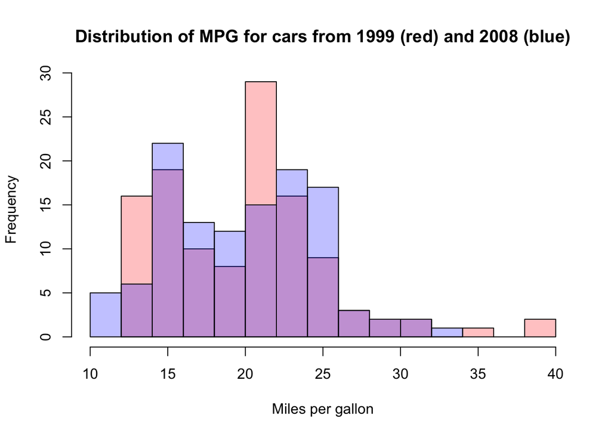

```r
plot(p1,col=rgb(1,0,0,1/4),xlab="Miles per gallon",ylab="Frequency",main="Distribution of MPG for cars from 1999 (red) and 2008 (blue)",xlim=c(10,40))
plot(p2,col=rgb(0,0,1,1/4),xlim=c(10,40),add = TRUE)
```

```r
summary(y1999)
```

```
##  manufacturer          model               displ            year
##  Length:117         Length:117         Min.   :1.600   Min.   :1999
##  Class :character   Class :character   1st Qu.:2.200   1st Qu.:1999
##  Mode  :character   Mode  :character   Median :3.000   Median :1999
##                                        Mean   :3.281   Mean   :1999
##                                        3rd Qu.:4.000   3rd Qu.:1999
##                                        Max.   :6.500   Max.   :1999
##       cyl           trans               drv                 cty
##  Min.   :4.000   Length:117         Length:117         Min.   :11.00
##  1st Qu.:4.000   Class :character   Class :character   1st Qu.:14.00
##  Median :6.000   Mode  :character   Mode  :character   Median :17.00
##  Mean   :5.692                                         Mean   :17.02
##  3rd Qu.:6.000                                         3rd Qu.:19.00
##  Max.   :8.000                                         Max.   :35.00
##       hwy             fl               class              mpg_avg
##  Min.   :15.00   Length:117         Length:117         Min.   :13.00
##  1st Qu.:17.00   Class :character   Class :character   1st Qu.:15.50
##  Median :25.00   Mode  :character   Mode  :character   Median :21.00
##  Mean   :23.43                                         Mean   :20.22
##  3rd Qu.:26.00                                         3rd Qu.:22.50
##  Max.   :44.00                                         Max.   :39.50
```

```r
summary(y2008)
```

```
##  manufacturer          model               displ            year
##  Length:117         Length:117         Min.   :1.800   Min.   :2008
##  Class :character   Class :character   1st Qu.:2.500   1st Qu.:2008
##  Mode  :character   Mode  :character   Median :3.600   Median :2008
##                                        Mean   :3.662   Mean   :2008
##                                        3rd Qu.:4.700   3rd Qu.:2008
##                                        Max.   :7.000   Max.   :2008
##       cyl           trans               drv                 cty
##  Min.   :4.000   Length:117         Length:117         Min.   : 9.0
##  1st Qu.:4.000   Class :character   Class :character   1st Qu.:13.0
##  Median :6.000   Mode  :character   Mode  :character   Median :17.0
##  Mean   :6.085                                         Mean   :16.7
##  3rd Qu.:8.000                                         3rd Qu.:20.0
##  Max.   :8.000                                         Max.   :28.0
##       hwy             fl               class              mpg_avg
##  Min.   :12.00   Length:117         Length:117         Min.   :10.50
##  1st Qu.:18.00   Class :character   Class :character   1st Qu.:16.00
##  Median :24.00   Mode  :character   Mode  :character   Median :20.50
##  Mean   :23.45                                         Mean   :20.08
##  3rd Qu.:28.00                                         3rd Qu.:23.50
##  Max.   :37.00                                         Max.   :32.50
```

The mean mpg value (averages) for 1999 are higher in the city and averaged categories. The mean highway mpg is higher in 2008 by .02 mpg. Overall, miles per gallon was higher on average in 1999.